# Fresh REPAIR simulations: full-system leverage, delete-one refitting, and bootstrap

2026-10-31

## Purpose and interpretation

**The full-system correction improves coverage over plain IF in several weak- information conditions, but at a substantial and sometimes extreme width cost. It is not a general replacement for person bootstrap inference.** Actual delete-one refits are much more widely available than the analytic methods, yet their symmetric Wald intervals still under-cover in several profiles.

Key fresh findings:

- Full IF and HC3 each return **756/1,200** analyses. All 444 refusals are the pre-existing singular-measurement gate; there are no additional HC3 sensitivity refusals or driver/API errors. Delete-one returns **1,192/1,200**; person percentile returns **1,158/1,200**. These are paired structural analyses, not independent measurement-dataset counts.
- At truth .40, hard-profile HC3 coverage is **86.7–95.8%**, versus **71.1–85.9%** for plain IF on exactly the same 45–65 eligible datasets/profile. Paired gains are about 10–16 percentage points in low balanced, negative-correlation, small/short and unequal-information profiles; their unadjusted paired MC intervals exclude zero. Low larger-N gains only 3.1 points (MC interval includes zero). These are exploratory comparisons, not multiplicity-adjusted claims.
- On common HC3/bootstrap datasets, the median ratio of HC3 to bootstrap width is **1.62–1.85** in the hard profiles. HC3’s 95th width percentiles are roughly **8.7–28.0**, versus **1.0–1.64** for bootstrap on their respective returned sets. No extreme intervals were capped or removed. Higher HC3 coverage often trades off detection and precision; mean SE alone obscures these tails.
- Delete-one effect coverage is **81.6–91.9%** in hard profiles, with 98–100 returned intervals/profile. Person-percentile coverage is **81.5–96.9%**, with 92–98 intervals. The small/short point bias remains **−.178** at truth .40; none of the variance methods changes the original coefficient.
- Analytic deletion shifts closely match actual deletions in the high-reliability control (median focal relative RMSE **.012**). Among common hard-profile datasets with a singularity/floor/final-branch deletion transition, median relative RMSE ranges **.55–1.33**. Without those transitions it is about **.027–.201**. These selected-subset diagnostics are consistent with limitations of local deletion approximations; they do not isolate a causal mechanism.
- All six remote R-platform checks pass. Independent study validation checks all endpoints, actual centered/uncentered covariance formulas, public APIs, fresh inputs, source hashes and B prefixes. Half-step sensitivity changes no availability decisions and changes matched covariance by at most **4.86e-7**.

This study tests a specified full-system HC3-style correction and actual whole-person delete-one refitting on **fresh random-number streams**. It is a 600-dataset exploratory validation screen: six profiles × 100 new measurement datasets, each with paired null and nonzero structural outcomes. Its purpose is to distinguish uncertainty propagation, leverage adjustment, refitting, interval construction, bias and numerical availability. It does not select a correction by maximizing observed coverage or claim uniform validity.

The numerical implementation and protocol were frozen before main results. Earlier experiments remain unchanged. All methods retain the original REPAIR point estimate; neither jackknife bias nor a simulation-estimated bias is subtracted from the interval center.

## Data-generating design and fresh samples

| profile | n | small | large | reliability | rho | tau | sigma | achieved_reliability | partial_reliability | reliability_small | reliability_large |
| --- | --- | --- | --- | --- | --- | --- | --- | --- | --- | --- | --- |
| low_balanced | 50 | 10 | 10 | 0.25 | 0.5 | 0.9 | 5.179 | 0.25 | 0.162 | 0.25 | 0.25 |
| low_negative | 50 | 10 | 10 | 0.25 | -0.5 | 0.9 | 5.179 | 0.25 | 0.162 | 0.25 | 0.25 |
| small_short | 30 | 3 | 3 | 0.25 | 0.5 | 0.9 | 2.504 | 0.25 | 0.156 | 0.25 | 0.25 |
| low_larger | 100 | 10 | 10 | 0.25 | 0.5 | 0.9 | 5.179 | 0.25 | 0.162 | 0.25 | 0.25 |
| high_control | 100 | 10 | 10 | 0.80 | 0.5 | 0.9 | 1.395 | 0.80 | 0.704 | 0.80 | 0.80 |
| low_unequal | 50 | 3 | 17 | 0.25 | 0.5 | 0.9 | 4.694 | 0.25 | 0.170 | 0.09 | 0.41 |

The design retains the earlier noisy-predictor experiment: within-person time is centered and sample-SD standardized; measurement Y=.5*time+b0+b1*time+eps; random intercept/slope SDs .9 and correlation +/−.5; Gaussian iid measurement errors calibrated to full-posterior slope reliability .25 or .8. The unequal profile assigns half the people to 3 and half to 17 observations independently of latent effects/errors.

The structural outcome is Z=1.5+.4*b0+(gamma/.9)*b1+eta, with Var(Z)=1, Gaussian homoskedastic eta and gamma=0/.40. Both recovered intercept and slope enter as noisy predictors. All focal coefficients, SEs and endpoints are multiplied by population SD .9. Gamma=0 is a null partial slope given the other noisy random coefficient, not necessarily a null marginal association.

New L’Ecuyer-CMRG master seed **202610319** replaces the old 202610301; bootstrap seed is 340000000+replication. Independent outer streams are paired across profiles, and null/effect outcomes share measurement data/noise. This gives 1,200 structural analyses, not 1,200 independent measurement datasets. The validation checks fresh input hashes against every old main-study input.

Main uses B499. The first three datasets/profile extend to B1999 and halve the analytic derivative step; no subset was chosen by its results. Development replication 801/B9 is excluded. No failed dataset is regenerated or replaced.

## What the methods estimate

**Conditional Wald** retains ordinary model-based M-MOM SEs. **Full IF Wald** uses the existing complete influence-function sandwich, including measurement estimation, structural weights/corrections and signed cross-stage covariance. Both full-system methods use exact ML/REML measurement equations, with the global REML fixed-design determinant retained. No ML scores at a REML fit are substituted.

**Full-system HC3 Wald** augments measurement parameters with unweighted observed/ error moments, weighted observed/error moments, log mean case weight and final corrected coefficient equations. All preliminary coefficients, variance floors, weights and correction multipliers are differentiated. Known error-free entries remain fixed. The mean-weight equation normalizes the final coefficient equation, cancelling an irrelevant common weight in OLS. That normalization was specified during pre-main development after an OLS acceptance test detected a spurious common-weight leverage effect.

For each person, solve the deleted augmented system’s Jacobian at the original parameters, using the exact deleted REML determinant. Sum **uncentered** outer products of the resulting coefficient shifts. This recovers ordinary OLS HC3 in the matching special case. No measurement model is refitted. Original N and policy/alpha remain fixed in this analytic structural correction. All deleted systems and the original full influence must be usable; failures are never silently replaced by HC0 or omitted. Sensitivities are centrally differentiated with half-step, one-sided and active-branch checks and scaled conditioning gates.

This is an explicitly specified **HC3-style nonlinear-system candidate**; leverage adjustments depend on the equation representation. It is not a derived CR2/Satterthwaite procedure or a theorem of nominal finite-sample coverage. The full derivation is in dev/leverage-jackknife-design.md in the PR. The OLS anchor and augmented HC0/canonical IF identity check validate implementation, not a general finite-sample approximation theorem.

**Delete-one Wald** refits each measurement and structural model on N-1 complete people, updating all finite-N corrections and weights. Its variance is (N-1)/N times the centered delete-one cross-product. Every complete coefficient vector is required; a failed deletion invalidates inference. Singular but converged native refits retain the existing replay policy and are recorded. Diagnostic jackknife bias is not subtracted. The analytic and actual deletion methods therefore differ in nonlinear re-estimation, finite-N updates, and HC3 versus centered jackknife scaling.

**Person percentile** samples N complete people and fully refits measurement and structural models, using the original complete-vector failure gate and type-7 percentile endpoints. **Bootstrap-SD Wald** instead uses the SD of those same bootstrap coefficients in a normal symmetric interval; it is not a percentile-t bootstrap. Frozen-measurement percentile and stage2 IF are diagnostic comparators. The unequal profile additionally retains a count-preserving stratified comparator. The earlier OLS-outcome stacked helper is not applied to this incompatible noisy- predictor estimand; OLS HC3 is checked independently in package tests.

Normal reference intervals are primary. HC3 and delete-one t_(N−1) intervals are prespecified secondary heuristics, not fitted effective degrees of freedom. There is no data-selected multiplier or hidden finite-sample correction.

## Availability is part of the result

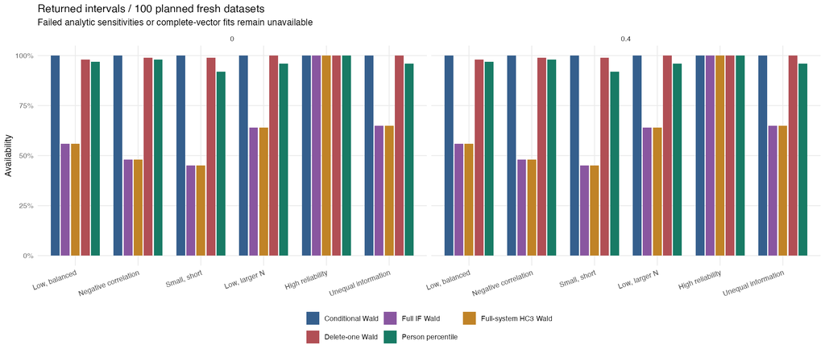

| singular | full_if | leverage | delete_one | Freq |
| --- | --- | --- | --- | --- |
| FALSE | FALSE | FALSE | FALSE | 0 |
| TRUE | FALSE | FALSE | FALSE | 2 |
| FALSE | TRUE | FALSE | FALSE | 0 |
| TRUE | TRUE | FALSE | FALSE | 0 |
| FALSE | FALSE | TRUE | FALSE | 0 |
| TRUE | FALSE | TRUE | FALSE | 0 |
| FALSE | TRUE | TRUE | FALSE | 6 |
| TRUE | TRUE | TRUE | FALSE | 0 |
| FALSE | FALSE | FALSE | TRUE | 0 |
| TRUE | FALSE | FALSE | TRUE | 442 |
| FALSE | TRUE | FALSE | TRUE | 0 |
| TRUE | TRUE | FALSE | TRUE | 0 |
| FALSE | FALSE | TRUE | TRUE | 0 |
| TRUE | FALSE | TRUE | TRUE | 0 |
| FALSE | TRUE | TRUE | TRUE | 750 |
| TRUE | TRUE | TRUE | TRUE | 0 |

Analytic inference refuses singular/weakly identified original measurement fits and unstable or weak deleted sensitivities. Actual refitting can remain usable at singular native covariances; that difference is explicit, not an error hidden by denominator changes. Every analytic refusal and native deletion failure is archived. Coverage and zero exclusion below use **available intervals only**; performance.csv also reports delivery-and-cover/detect per all 100 planned data. Unavailable intervals remain NA, never valid non-rejections.

## Nonzero-effect coverage, detection and width

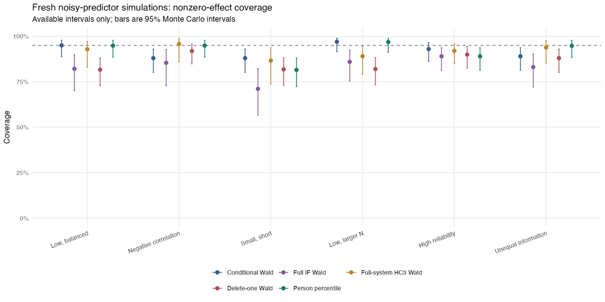

| Profile | Method | Intervals / 100 | Coverage | Zero exclusion | Median width | 95th width percentile |
| --- | --- | --- | --- | --- | --- | --- |
| low_balanced | Conditional Wald | 100 | 0.950 | 0.030 | 1.307 | 3.273 |
| low_balanced | Full IF Wald | 56 | 0.821 | 0.214 | 0.858 | 3.017 |
| low_balanced | Full-system HC3 Wald | 56 | 0.929 | 0.143 | 1.365 | 19.319 |
| low_balanced | Delete-one Wald | 98 | 0.816 | 0.255 | 1.051 | 2.386 |
| low_balanced | Person percentile | 97 | 0.948 | 0.258 | 0.818 | 1.350 |
| low_negative | Conditional Wald | 100 | 0.880 | 0.010 | 1.646 | 3.649 |
| low_negative | Full IF Wald | 48 | 0.854 | 0.104 | 0.970 | 3.247 |
| low_negative | Full-system HC3 Wald | 48 | 0.958 | 0.083 | 1.695 | 26.307 |
| low_negative | Delete-one Wald | 99 | 0.919 | 0.182 | 1.172 | 2.666 |
| low_negative | Person percentile | 98 | 0.949 | 0.092 | 0.989 | 1.611 |
| small_short | Conditional Wald | 100 | 0.880 | 0.070 | 1.058 | 1.976 |
| small_short | Full IF Wald | 45 | 0.711 | 0.244 | 0.725 | 1.298 |
| small_short | Full-system HC3 Wald | 45 | 0.867 | 0.133 | 1.199 | 8.717 |
| small_short | Delete-one Wald | 99 | 0.818 | 0.202 | 0.877 | 1.589 |
| small_short | Person percentile | 92 | 0.815 | 0.141 | 0.700 | 0.994 |
| low_larger | Conditional Wald | 100 | 0.970 | 0.050 | 2.286 | 5.746 |
| low_larger | Full IF Wald | 64 | 0.859 | 0.219 | 1.143 | 3.484 |
| low_larger | Full-system HC3 Wald | 64 | 0.891 | 0.156 | 1.560 | 11.182 |
| low_larger | Delete-one Wald | 100 | 0.820 | 0.210 | 1.388 | 3.448 |
| low_larger | Person percentile | 96 | 0.969 | 0.250 | 1.142 | 1.644 |
| high_control | Conditional Wald | 100 | 0.930 | 0.940 | 0.432 | 0.567 |
| high_control | Full IF Wald | 100 | 0.890 | 0.950 | 0.424 | 0.592 |
| high_control | Full-system HC3 Wald | 100 | 0.920 | 0.920 | 0.457 | 0.658 |
| high_control | Delete-one Wald | 100 | 0.900 | 0.920 | 0.449 | 0.648 |
| high_control | Person percentile | 100 | 0.890 | 0.930 | 0.463 | 0.673 |
| low_unequal | Conditional Wald | 100 | 0.890 | 0.300 | 0.981 | 2.600 |
| low_unequal | Full IF Wald | 65 | 0.831 | 0.292 | 0.951 | 2.163 |
| low_unequal | Full-system HC3 Wald | 65 | 0.938 | 0.169 | 1.595 | 27.961 |
| low_unequal | Delete-one Wald | 100 | 0.880 | 0.260 | 1.188 | 2.726 |
| low_unequal | Person percentile | 96 | 0.948 | 0.271 | 0.900 | 1.402 |

Zero exclusion here is detection, not type-I error. Median width can conceal extreme intervals, so the 95th width percentile is also shown. All five methods share original coefficients; the CSV retains overall and eligible bias/SD and mean SEs rather than treating higher coverage alone as evidence of better inference.

## Null-effect coverage and rejection

| Profile | Method | Intervals / 100 | Coverage | Zero exclusion | Median width | 95th width percentile |
| --- | --- | --- | --- | --- | --- | --- |
| low_balanced | Conditional Wald | 100 | 0.990 | 0.010 | 1.464 | 3.552 |
| low_balanced | Full IF Wald | 56 | 0.929 | 0.071 | 0.964 | 2.531 |
| low_balanced | Full-system HC3 Wald | 56 | 0.929 | 0.071 | 1.484 | 15.047 |
| low_balanced | Delete-one Wald | 98 | 0.867 | 0.133 | 1.242 | 2.701 |
| low_balanced | Person percentile | 97 | 0.948 | 0.052 | 1.012 | 1.481 |
| low_negative | Conditional Wald | 100 | 1.000 | 0.000 | 1.457 | 3.687 |
| low_negative | Full IF Wald | 48 | 0.958 | 0.042 | 1.014 | 2.575 |
| low_negative | Full-system HC3 Wald | 48 | 1.000 | 0.000 | 1.625 | 33.148 |
| low_negative | Delete-one Wald | 99 | 0.949 | 0.051 | 1.404 | 2.653 |
| low_negative | Person percentile | 98 | 0.969 | 0.031 | 1.037 | 1.481 |
| small_short | Conditional Wald | 100 | 0.990 | 0.010 | 1.072 | 2.031 |
| small_short | Full IF Wald | 45 | 0.933 | 0.067 | 0.730 | 1.293 |
| small_short | Full-system HC3 Wald | 45 | 1.000 | 0.000 | 1.293 | 5.398 |
| small_short | Delete-one Wald | 99 | 0.899 | 0.101 | 1.031 | 1.807 |
| small_short | Person percentile | 92 | 0.978 | 0.022 | 0.807 | 1.100 |
| low_larger | Conditional Wald | 100 | 0.990 | 0.010 | 1.961 | 6.353 |
| low_larger | Full IF Wald | 64 | 0.938 | 0.062 | 1.075 | 4.729 |
| low_larger | Full-system HC3 Wald | 64 | 0.953 | 0.047 | 1.389 | 28.565 |
| low_larger | Delete-one Wald | 100 | 0.890 | 0.110 | 1.585 | 3.762 |
| low_larger | Person percentile | 96 | 0.958 | 0.042 | 1.429 | 1.986 |
| high_control | Conditional Wald | 100 | 0.920 | 0.080 | 0.512 | 0.667 |
| high_control | Full IF Wald | 100 | 0.890 | 0.110 | 0.505 | 0.686 |
| high_control | Full-system HC3 Wald | 100 | 0.920 | 0.080 | 0.540 | 0.748 |
| high_control | Delete-one Wald | 100 | 0.900 | 0.100 | 0.532 | 0.737 |
| high_control | Person percentile | 100 | 0.900 | 0.100 | 0.539 | 0.775 |
| low_unequal | Conditional Wald | 100 | 0.800 | 0.200 | 0.906 | 2.935 |
| low_unequal | Full IF Wald | 65 | 0.908 | 0.092 | 1.010 | 2.715 |
| low_unequal | Full-system HC3 Wald | 65 | 0.938 | 0.062 | 2.524 | 29.472 |
| low_unequal | Delete-one Wald | 100 | 0.880 | 0.120 | 1.474 | 2.874 |
| low_unequal | Person percentile | 96 | 0.917 | 0.083 | 1.093 | 1.552 |

At 100 planned datasets, a coverage near .95 has MC SE approximately .022. Smaller eligible subsets have wider uncertainty. Figure bars and the CSV give Wilson 95% Monte Carlo intervals; few-point changes do not establish superiority.

## Comparisons on common eligible datasets

| profile | method_a | method_b | n | difference | mc_low | mc_high | a_only | b_only |
| --- | --- | --- | --- | --- | --- | --- | --- | --- |
| low_balanced | Full-system HC3 Wald | Full IF Wald | 56 | 0.107 | 0.025 | 0.189 | 6 | 0 |
| low_balanced | Full-system HC3 Wald | Person percentile | 55 | -0.036 | -0.108 | 0.035 | 1 | 3 |
| low_balanced | Delete-one Wald | Person percentile | 95 | -0.126 | -0.193 | -0.059 | 0 | 12 |
| low_balanced | Full-system HC3 Wald | Delete-one Wald | 54 | 0.074 | 0.004 | 0.145 | 4 | 0 |
| low_negative | Full-system HC3 Wald | Full IF Wald | 48 | 0.104 | 0.017 | 0.191 | 5 | 0 |
| low_negative | Full-system HC3 Wald | Person percentile | 48 | 0.021 | -0.050 | 0.092 | 2 | 1 |
| low_negative | Delete-one Wald | Person percentile | 97 | -0.031 | -0.084 | 0.022 | 2 | 5 |
| low_negative | Full-system HC3 Wald | Delete-one Wald | 47 | 0.021 | -0.020 | 0.063 | 1 | 0 |
| small_short | Full-system HC3 Wald | Full IF Wald | 45 | 0.156 | 0.048 | 0.263 | 7 | 0 |
| small_short | Full-system HC3 Wald | Person percentile | 41 | 0.049 | -0.087 | 0.185 | 5 | 3 |
| small_short | Delete-one Wald | Person percentile | 91 | 0.000 | -0.053 | 0.053 | 3 | 3 |
| small_short | Full-system HC3 Wald | Delete-one Wald | 45 | 0.111 | 0.018 | 0.204 | 5 | 0 |
| low_larger | Full-system HC3 Wald | Full IF Wald | 64 | 0.031 | -0.012 | 0.074 | 2 | 0 |
| low_larger | Full-system HC3 Wald | Person percentile | 62 | -0.065 | -0.126 | -0.003 | 0 | 4 |
| low_larger | Delete-one Wald | Person percentile | 96 | -0.146 | -0.217 | -0.075 | 0 | 14 |
| low_larger | Full-system HC3 Wald | Delete-one Wald | 64 | 0.031 | -0.012 | 0.074 | 2 | 0 |
| high_control | Full-system HC3 Wald | Full IF Wald | 100 | 0.030 | -0.004 | 0.064 | 3 | 0 |
| high_control | Full-system HC3 Wald | Person percentile | 100 | 0.030 | -0.004 | 0.064 | 3 | 0 |
| high_control | Delete-one Wald | Person percentile | 100 | 0.010 | -0.010 | 0.030 | 1 | 0 |
| high_control | Full-system HC3 Wald | Delete-one Wald | 100 | 0.020 | -0.008 | 0.048 | 2 | 0 |
| low_unequal | Full-system HC3 Wald | Full IF Wald | 65 | 0.108 | 0.032 | 0.184 | 7 | 0 |
| low_unequal | Full-system HC3 Wald | Person percentile | 61 | -0.016 | -0.072 | 0.040 | 1 | 2 |
| low_unequal | Delete-one Wald | Person percentile | 96 | -0.073 | -0.125 | -0.021 | 0 | 7 |
| low_unequal | Full-system HC3 Wald | Delete-one Wald | 65 | 0.062 | 0.003 | 0.120 | 4 | 0 |

Differences are method A minus method B. Bounds use paired per-dataset decision differences and are exploratory, without multiplicity adjustment. No observed discordance is not proof of equivalence; such bounds are not asserted. These matched comparisons distinguish eligibility selection from interval construction.

## Secondary references and interval construction

| Profile | Method | Intervals / 100 | Coverage | Zero exclusion | Median width | 95th width percentile |
| --- | --- | --- | --- | --- | --- | --- |
| low_balanced | Full-system HC3 Wald | 56 | 0.929 | 0.143 | 1.365 | 19.319 |
| low_balanced | Full-system HC3 t | 56 | 0.946 | 0.143 | 1.400 | 19.808 |
| low_balanced | Delete-one Wald | 98 | 0.816 | 0.255 | 1.051 | 2.386 |
| low_balanced | Delete-one t | 98 | 0.827 | 0.245 | 1.078 | 2.447 |
| low_balanced | Bootstrap-SD Wald | 97 | 0.866 | 0.371 | 0.862 | 1.525 |
| low_balanced | Person percentile | 97 | 0.948 | 0.258 | 0.818 | 1.350 |
| low_negative | Full-system HC3 Wald | 48 | 0.958 | 0.083 | 1.695 | 26.307 |
| low_negative | Full-system HC3 t | 48 | 0.958 | 0.083 | 1.738 | 26.973 |
| low_negative | Delete-one Wald | 99 | 0.919 | 0.182 | 1.172 | 2.666 |
| low_negative | Delete-one t | 99 | 0.919 | 0.182 | 1.201 | 2.733 |
| low_negative | Bootstrap-SD Wald | 98 | 0.878 | 0.245 | 1.035 | 1.710 |
| low_negative | Person percentile | 98 | 0.949 | 0.092 | 0.989 | 1.611 |
| small_short | Full-system HC3 Wald | 45 | 0.867 | 0.133 | 1.199 | 8.717 |
| small_short | Full-system HC3 t | 45 | 0.889 | 0.133 | 1.251 | 9.096 |
| small_short | Delete-one Wald | 99 | 0.818 | 0.202 | 0.877 | 1.589 |
| small_short | Delete-one t | 99 | 0.818 | 0.182 | 0.915 | 1.658 |
| small_short | Bootstrap-SD Wald | 92 | 0.750 | 0.239 | 0.719 | 1.051 |
| small_short | Person percentile | 92 | 0.815 | 0.141 | 0.700 | 0.994 |
| low_larger | Full-system HC3 Wald | 64 | 0.891 | 0.156 | 1.560 | 11.182 |
| low_larger | Full-system HC3 t | 64 | 0.891 | 0.156 | 1.579 | 11.321 |
| low_larger | Delete-one Wald | 100 | 0.820 | 0.210 | 1.388 | 3.448 |
| low_larger | Delete-one t | 100 | 0.820 | 0.210 | 1.405 | 3.490 |
| low_larger | Bootstrap-SD Wald | 96 | 0.885 | 0.312 | 1.208 | 1.919 |
| low_larger | Person percentile | 96 | 0.969 | 0.250 | 1.142 | 1.644 |
| high_control | Full-system HC3 Wald | 100 | 0.920 | 0.920 | 0.457 | 0.658 |
| high_control | Full-system HC3 t | 100 | 0.920 | 0.920 | 0.462 | 0.666 |
| high_control | Delete-one Wald | 100 | 0.900 | 0.920 | 0.449 | 0.648 |
| high_control | Delete-one t | 100 | 0.920 | 0.920 | 0.455 | 0.656 |
| high_control | Bootstrap-SD Wald | 100 | 0.900 | 0.930 | 0.462 | 0.668 |
| high_control | Person percentile | 100 | 0.890 | 0.930 | 0.463 | 0.673 |
| low_unequal | Full-system HC3 Wald | 65 | 0.938 | 0.169 | 1.595 | 27.961 |
| low_unequal | Full-system HC3 t | 65 | 0.938 | 0.169 | 1.635 | 28.669 |
| low_unequal | Delete-one Wald | 100 | 0.880 | 0.260 | 1.188 | 2.726 |
| low_unequal | Delete-one t | 100 | 0.890 | 0.260 | 1.218 | 2.795 |
| low_unequal | Bootstrap-SD Wald | 96 | 0.885 | 0.396 | 0.917 | 1.547 |
| low_unequal | Person percentile | 96 | 0.948 | 0.271 | 0.900 | 1.402 |

## Branches, leverage and exact deletion

| profile | gamma | method | state | planned | available | coverage | rejection |
| --- | --- | --- | --- | --- | --- | --- | --- |
| low_balanced | 0.4 | Conditional Wald | Active correction/floor | 23 | 23 | 1.000 | 0.043 |
| low_larger | 0.4 | Conditional Wald | Active correction/floor | 9 | 9 | 1.000 | 0.000 |
| low_negative | 0.4 | Conditional Wald | Active correction/floor | 12 | 12 | 1.000 | 0.000 |
| low_unequal | 0.4 | Conditional Wald | Active correction/floor | 49 | 49 | 0.939 | 0.490 |
| small_short | 0.4 | Conditional Wald | Active correction/floor | 18 | 18 | 0.833 | 0.111 |
| low_balanced | 0.4 | Delete-one Wald | Active correction/floor | 23 | 21 | 0.762 | 0.381 |
| low_larger | 0.4 | Delete-one Wald | Active correction/floor | 9 | 9 | 0.444 | 0.778 |
| low_negative | 0.4 | Delete-one Wald | Active correction/floor | 12 | 11 | 1.000 | 0.364 |
| low_unequal | 0.4 | Delete-one Wald | Active correction/floor | 49 | 49 | 0.857 | 0.367 |
| small_short | 0.4 | Delete-one Wald | Active correction/floor | 18 | 18 | 0.667 | 0.278 |
| low_balanced | 0.4 | Full IF Wald | Active correction/floor | 23 | 23 | 0.739 | 0.391 |
| low_larger | 0.4 | Full IF Wald | Active correction/floor | 9 | 9 | 0.444 | 0.778 |
| low_negative | 0.4 | Full IF Wald | Active correction/floor | 12 | 12 | 0.917 | 0.333 |
| low_unequal | 0.4 | Full IF Wald | Active correction/floor | 49 | 49 | 0.796 | 0.388 |
| small_short | 0.4 | Full IF Wald | Active correction/floor | 18 | 18 | 0.667 | 0.333 |
| low_balanced | 0.4 | Full-system HC3 Wald | Active correction/floor | 23 | 23 | 0.913 | 0.304 |
| low_larger | 0.4 | Full-system HC3 Wald | Active correction/floor | 9 | 9 | 0.667 | 0.778 |
| low_negative | 0.4 | Full-system HC3 Wald | Active correction/floor | 12 | 12 | 1.000 | 0.250 |
| low_unequal | 0.4 | Full-system HC3 Wald | Active correction/floor | 49 | 49 | 0.939 | 0.224 |
| small_short | 0.4 | Full-system HC3 Wald | Active correction/floor | 18 | 18 | 0.889 | 0.222 |
| low_balanced | 0.4 | Person percentile | Active correction/floor | 23 | 23 | 0.957 | 0.391 |
| low_larger | 0.4 | Person percentile | Active correction/floor | 9 | 9 | 0.778 | 0.556 |
| low_negative | 0.4 | Person percentile | Active correction/floor | 12 | 12 | 1.000 | 0.167 |
| low_unequal | 0.4 | Person percentile | Active correction/floor | 49 | 46 | 0.935 | 0.413 |
| small_short | 0.4 | Person percentile | Active correction/floor | 18 | 16 | 0.688 | 0.188 |
| high_control | 0.4 | Conditional Wald | Interior structural branch | 100 | 100 | 0.930 | 0.940 |
| low_balanced | 0.4 | Conditional Wald | Interior structural branch | 33 | 33 | 0.939 | 0.061 |
| low_larger | 0.4 | Conditional Wald | Interior structural branch | 55 | 55 | 0.945 | 0.073 |
| low_negative | 0.4 | Conditional Wald | Interior structural branch | 36 | 36 | 0.806 | 0.000 |
| low_unequal | 0.4 | Conditional Wald | Interior structural branch | 16 | 16 | 0.875 | 0.000 |
| small_short | 0.4 | Conditional Wald | Interior structural branch | 27 | 27 | 0.741 | 0.074 |
| high_control | 0.4 | Delete-one Wald | Interior structural branch | 100 | 100 | 0.900 | 0.920 |
| low_balanced | 0.4 | Delete-one Wald | Interior structural branch | 33 | 33 | 0.909 | 0.091 |
| low_larger | 0.4 | Delete-one Wald | Interior structural branch | 55 | 55 | 0.927 | 0.055 |
| low_negative | 0.4 | Delete-one Wald | Interior structural branch | 36 | 36 | 0.917 | 0.028 |
| low_unequal | 0.4 | Delete-one Wald | Interior structural branch | 16 | 16 | 0.938 | 0.000 |
| small_short | 0.4 | Delete-one Wald | Interior structural branch | 27 | 27 | 0.815 | 0.111 |
| high_control | 0.4 | Full IF Wald | Interior structural branch | 100 | 100 | 0.890 | 0.950 |
| low_balanced | 0.4 | Full IF Wald | Interior structural branch | 33 | 33 | 0.879 | 0.091 |
| low_larger | 0.4 | Full IF Wald | Interior structural branch | 55 | 55 | 0.927 | 0.127 |
| low_negative | 0.4 | Full IF Wald | Interior structural branch | 36 | 36 | 0.833 | 0.028 |
| low_unequal | 0.4 | Full IF Wald | Interior structural branch | 16 | 16 | 0.938 | 0.000 |
| small_short | 0.4 | Full IF Wald | Interior structural branch | 27 | 27 | 0.741 | 0.185 |
| high_control | 0.4 | Full-system HC3 Wald | Interior structural branch | 100 | 100 | 0.920 | 0.920 |
| low_balanced | 0.4 | Full-system HC3 Wald | Interior structural branch | 33 | 33 | 0.939 | 0.030 |
| low_larger | 0.4 | Full-system HC3 Wald | Interior structural branch | 55 | 55 | 0.927 | 0.055 |
| low_negative | 0.4 | Full-system HC3 Wald | Interior structural branch | 36 | 36 | 0.944 | 0.028 |
| low_unequal | 0.4 | Full-system HC3 Wald | Interior structural branch | 16 | 16 | 0.938 | 0.000 |
| small_short | 0.4 | Full-system HC3 Wald | Interior structural branch | 27 | 27 | 0.852 | 0.074 |
| high_control | 0.4 | Person percentile | Interior structural branch | 100 | 100 | 0.890 | 0.930 |
| low_balanced | 0.4 | Person percentile | Interior structural branch | 33 | 32 | 0.969 | 0.125 |
| low_larger | 0.4 | Person percentile | Interior structural branch | 55 | 53 | 0.981 | 0.226 |
| low_negative | 0.4 | Person percentile | Interior structural branch | 36 | 36 | 0.917 | 0.056 |
| low_unequal | 0.4 | Person percentile | Interior structural branch | 16 | 15 | 1.000 | 0.200 |
| small_short | 0.4 | Person percentile | Interior structural branch | 27 | 25 | 0.880 | 0.080 |
| low_balanced | 0.4 | Conditional Wald | Singular measurement | 44 | 44 | 0.932 | 0.000 |
| low_larger | 0.4 | Conditional Wald | Singular measurement | 36 | 36 | 1.000 | 0.028 |
| low_negative | 0.4 | Conditional Wald | Singular measurement | 52 | 52 | 0.904 | 0.019 |
| low_unequal | 0.4 | Conditional Wald | Singular measurement | 35 | 35 | 0.829 | 0.171 |
| small_short | 0.4 | Conditional Wald | Singular measurement | 55 | 55 | 0.964 | 0.055 |
| low_balanced | 0.4 | Delete-one Wald | Singular measurement | 44 | 44 | 0.773 | 0.318 |
| low_larger | 0.4 | Delete-one Wald | Singular measurement | 36 | 36 | 0.750 | 0.306 |
| low_negative | 0.4 | Delete-one Wald | Singular measurement | 52 | 52 | 0.904 | 0.250 |
| low_unequal | 0.4 | Delete-one Wald | Singular measurement | 35 | 35 | 0.886 | 0.229 |
| small_short | 0.4 | Delete-one Wald | Singular measurement | 55 | 54 | 0.870 | 0.222 |
| low_balanced | 0.4 | Full IF Wald | Singular measurement | 44 | 0 | NA | NA |
| low_larger | 0.4 | Full IF Wald | Singular measurement | 36 | 0 | NA | NA |
| low_negative | 0.4 | Full IF Wald | Singular measurement | 52 | 0 | NA | NA |
| low_unequal | 0.4 | Full IF Wald | Singular measurement | 35 | 0 | NA | NA |
| small_short | 0.4 | Full IF Wald | Singular measurement | 55 | 0 | NA | NA |
| low_balanced | 0.4 | Full-system HC3 Wald | Singular measurement | 44 | 0 | NA | NA |
| low_larger | 0.4 | Full-system HC3 Wald | Singular measurement | 36 | 0 | NA | NA |
| low_negative | 0.4 | Full-system HC3 Wald | Singular measurement | 52 | 0 | NA | NA |
| low_unequal | 0.4 | Full-system HC3 Wald | Singular measurement | 35 | 0 | NA | NA |
| small_short | 0.4 | Full-system HC3 Wald | Singular measurement | 55 | 0 | NA | NA |
| low_balanced | 0.4 | Person percentile | Singular measurement | 44 | 42 | 0.929 | 0.286 |
| low_larger | 0.4 | Person percentile | Singular measurement | 36 | 34 | 1.000 | 0.206 |
| low_negative | 0.4 | Person percentile | Singular measurement | 52 | 50 | 0.960 | 0.100 |
| low_unequal | 0.4 | Person percentile | Singular measurement | 35 | 35 | 0.943 | 0.114 |
| small_short | 0.4 | Person percentile | Singular measurement | 55 | 51 | 0.824 | 0.157 |

“Interior structural branch” means alpha:positive:alpha at a nonsingular original measurement fit. “Active correction/floor” includes the other structural branches; singular measurement fits have their own stratum. These are observational diagnostic strata with different sample selection, not randomized causal contrasts. Small strata are descriptive. Per-deletion floor/correction/singularity records are retained separately in deletion_diagnostics.rds.

| profile | gamma | usable | singular_deletions | floor_switches | final_branch_switches |
| --- | --- | --- | --- | --- | --- |
| high_control | 0.0 | 100.00 | 0.00 | 0.00 | 0.00 |
| low_balanced | 0.0 | 49.98 | 23.09 | 2.83 | 2.55 |
| low_larger | 0.0 | 100.00 | 36.07 | 1.55 | 1.62 |
| low_negative | 0.0 | 49.99 | 26.44 | 1.67 | 1.98 |
| low_unequal | 0.0 | 50.00 | 17.63 | 1.37 | 2.02 |
| small_short | 0.0 | 29.99 | 16.69 | 1.39 | 1.43 |
| high_control | 0.4 | 100.00 | 0.00 | 0.00 | 0.00 |
| low_balanced | 0.4 | 49.98 | 23.09 | 3.11 | 2.22 |
| low_larger | 0.4 | 100.00 | 36.07 | 1.37 | 1.81 |
| low_negative | 0.4 | 49.99 | 26.44 | 2.26 | 2.41 |
| low_unequal | 0.4 | 50.00 | 17.63 | 0.98 | 1.97 |
| small_short | 0.4 | 29.99 | 16.69 | 1.35 | 0.95 |

These counts refer to usable structural deletions (with their explicit counts) and actual singular native refits. Final-branch changes distinguish the root multiplier from the fixed-alpha multiplier using the declared minimum policy and updated N-1; changes merely caused by alpha/(N-1) are not called branch switches. Counts are descriptive and do not repair selection from failed fits.

Medians of available HC3 covariance contributions and ratios:

| profile | full | direct | measurement | cross | to_hc0 |
| --- | --- | --- | --- | --- | --- |
| high_control | 0.016 | 0.016 | 0.000 | 0.000 | 1.149 |
| low_balanced | 0.134 | 0.130 | 0.001 | 0.002 | 2.403 |
| low_larger | 0.141 | 0.137 | 0.002 | 0.001 | 1.656 |
| low_negative | 0.177 | 0.171 | 0.001 | 0.002 | 3.007 |
| low_unequal | 0.252 | 0.247 | 0.003 | 0.001 | 3.233 |
| small_short | 0.105 | 0.086 | 0.005 | 0.001 | 2.324 |

The cross contribution is signed and need not increase the total variance. Actual versus analytic deletion shifts on common available datasets:

| profile | relative_shift_rmse | focal_relative_shift_rmse | leverage_variance | jackknife_variance |
| --- | --- | --- | --- | --- |
| high_control | 0.020 | 0.011 | 0.016 | 0.016 |
| low_balanced | 0.603 | 0.501 | 0.139 | 0.075 |
| low_larger | 0.094 | 0.071 | 0.141 | 0.118 |
| low_negative | 0.413 | 0.335 | 0.175 | 0.107 |
| low_unequal | 0.929 | 0.937 | 0.252 | 0.103 |
| small_short | 0.588 | 0.323 | 0.105 | 0.050 |

The relative RMSE divides the sum of squared analytic-minus-actual shifts by the sum of squared actual shifts (with a small numerical floor). A discrepancy can reflect curvature, branch changes, finite-N policy updates and centering/ scaling conventions; it is not automatically an implementation error. HC0 identity and OLS HC3 tests provide independent implementation anchors.

| profile | deletion_transition | n | median |
| --- | --- | --- | --- |
| high_control | FALSE | 100 | 0.012 |
| low_balanced | FALSE | 12 | 0.048 |
| low_larger | FALSE | 29 | 0.027 |
| low_negative | FALSE | 18 | 0.045 |
| low_unequal | FALSE | 7 | 0.201 |
| small_short | FALSE | 15 | 0.100 |
| low_balanced | TRUE | 42 | 0.834 |
| low_larger | TRUE | 35 | 0.553 |
| low_negative | TRUE | 29 | 1.326 |
| low_unequal | TRUE | 58 | 0.892 |
| small_short | TRUE | 30 | 1.063 |

The transition label indicates at least one actual deletion becoming singular or changing floor/final-correction branch. These selected-subset comparisons describe approximation behavior and do not establish causal effects of a branch.

## Prespecified sensitivity and independent validation

| profile | rep | gamma | same | relative |
| --- | --- | --- | --- | --- |
| low_balanced | 1 | 0.0 | TRUE | NA |
| low_balanced | 1 | 0.4 | TRUE | NA |
| low_balanced | 2 | 0.0 | TRUE | 0 |
| low_balanced | 2 | 0.4 | TRUE | 0 |
| low_balanced | 3 | 0.0 | TRUE | 0 |
| low_balanced | 3 | 0.4 | TRUE | 0 |
| low_negative | 1 | 0.0 | TRUE | NA |
| low_negative | 1 | 0.4 | TRUE | NA |
| low_negative | 2 | 0.0 | TRUE | 0 |
| low_negative | 2 | 0.4 | TRUE | 0 |
| low_negative | 3 | 0.0 | TRUE | 0 |
| low_negative | 3 | 0.4 | TRUE | 0 |
| small_short | 1 | 0.0 | TRUE | 0 |
| small_short | 1 | 0.4 | TRUE | 0 |
| small_short | 2 | 0.0 | TRUE | 0 |
| small_short | 2 | 0.4 | TRUE | 0 |
| small_short | 3 | 0.0 | TRUE | NA |
| small_short | 3 | 0.4 | TRUE | NA |
| low_larger | 1 | 0.0 | TRUE | NA |
| low_larger | 1 | 0.4 | TRUE | NA |
| low_larger | 2 | 0.0 | TRUE | NA |
| low_larger | 2 | 0.4 | TRUE | NA |
| low_larger | 3 | 0.0 | TRUE | NA |
| low_larger | 3 | 0.4 | TRUE | NA |
| high_control | 1 | 0.0 | TRUE | 0 |
| high_control | 1 | 0.4 | TRUE | 0 |
| high_control | 2 | 0.0 | TRUE | 0 |
| high_control | 2 | 0.4 | TRUE | 0 |
| high_control | 3 | 0.0 | TRUE | 0 |
| high_control | 3 | 0.4 | TRUE | 0 |
| low_unequal | 1 | 0.0 | TRUE | 0 |
| low_unequal | 1 | 0.4 | TRUE | 0 |
| low_unequal | 2 | 0.0 | TRUE | 0 |
| low_unequal | 2 | 0.4 | TRUE | 0 |
| low_unequal | 3 | 0.0 | TRUE | 0 |
| low_unequal | 3 | 0.4 | TRUE | 0 |

Availability changes under half steps and matched covariance differences are reported without choosing the better-performing step. The B1999 subset retains exact B499 prefixes; endpoint/availability changes are archived in bootstrap_sensitivity.csv. This small tail subset is not a high-precision coverage experiment.

All 78 fixed-subset percentile intervals were available at B499; **six become unavailable at B1999** under the unchanged all-vector failure rule. Among the 72 returned at both B values, coverage classification is unchanged (all cover). Median sums of absolute lower/upper endpoint changes are .0246 for person percentile, .0310 frozen, and .0326 stratified. The sensitivity comparison preserves those lost intervals; it does not silently condition the primary analysis on successes or replace failures with new draws.

A **separate post hoc numerical audit**, motivated by the unusually wide tails, checked the 12 largest HC3/HC0 variance ratios at h/2 and h/4. All 24 comparisons remained available; the largest relative full-covariance change was **1.06e-4** (about .011%). This supports treating the large corrections as properties of the specified approximation rather than gross differencing error. It is not a prespecified coverage comparison or proof of exact numerical precision. No main estimate, step, threshold or interval was replaced. The rule and outputs are retained in audit_extremes.R and posthoc_extreme_audit.csv.

The computational shortcut caches immutable individual OLS/design-inverse ingredients for this iid matching-design DGP. **Every bootstrap and delete-one measurement model is actually optimized**, with its fixed coefficients/sigma and all structural equations updated. Eligibility requires full coefficient vectors, not just a finite focal slope. Fixed subsets are verified against 24 complete public B99 bootstraps and 12 complete public jackknives. No failed vector is replaced, trimmed or silently accepted.

```
PASS 600 fresh main and 18 sensitivity checkpoints; no driver/API errors.
PASS frozen source, reference and installed-library hashes.
PASS 12,200 endpoints / 122 performance cells independently recomputed; missing intervals remain NA.
PASS 24 public B99 bootstrap calls / 2376 attempts; 12 complete public jackknives / 760 deletions; max coefficient gap 2.93e-14.
PASS HC3 uncentered shift covariance, signed decomposition and IDs; max decomposition error 6.31e-16 / augmented HC0 relative gap 6.16e-06.
PASS exact centered delete-one covariance, strict complete-vector gates and recorded percentile endpoints.
PASS B499 arrays are exact B1999 prefixes for draws, eligibility and full/frozen coefficients.
PASS 600 distinct fresh input hashes; none equals any of the 600 old study inputs.
Half-step sensitivity: 0 changed availability decisions; max matched relative covariance change 4.86e-07.
```

## Reproducibility and limits

Numerical baseline is repair cbffe31, built on PR #21 head 6bb14dc. Subsequent documentation and an explicit utils::tail qualification preserve the equations; the frozen installed simulation library is not overwritten. The protocol, drivers, source/library/reference hashes, sessions and full native histories are retained in the research workspace’s leverage_fresh directory. The PR’s dev/leverage-simulation bundle permits independent endpoint/rate verification without fitting hundreds of thousands of models. Its README explains the external research-source dependencies and distinguishes compact review evidence from a complete raw optimization archive.

These results cover Gaussian iid measurement errors, six fixed reliability/ schedule conditions and a particular noisy-predictor structural design. They do not validate informative missingness, misspecification, shared nuisance effects, multiple measurement models or uniform boundary coverage. Neither a finite interval nor an exact covariance decomposition establishes calibrated inference; point bias, width, power and availability remain part of the assessment.

The package therefore retains both new methods as opt-in experimental tools. The leverage result is useful for inspecting the complete system’s sensitivity; actual delete-one refits provide a complementary influence/branch diagnostic. These results do not support making either symmetric interval the default solution for weak noisy predictors. Bootstrap likewise remains imperfect, especially with short panels and boundary/convergence issues.